# Harrell’s added predictive performance yardstick (HAPPY)

Published

September 16, 2023

Harrell’s added predictive performance yardstick (HAPPY)[^1]

## Background

`Happy` computes several statistical indexes (“yardsticks”) to quantify the added predictive performance of “new” predictors over “old” predictors in binary and ordinal outcome models. This `R` function is inspired by Prof Harrell’s thoughtful and thought-provoking blog article, [Statistically Efficient Ways to Quantify Added Predictive Value of New Measurements](https://www.fharrell.com/post/addvalue/), and his more recent thinking about the [modified adjusted Maddala-Cox-Snell $R^2$ values](https://hbiostat.org/bib/r2.html).

## Summary of Yardsticks

### Yardstick 1

$U$-statistic test, implemented in [`Hmisc::rcorrp.cens()`](https://www.rdocumentation.org/packages/Hmisc/versions/3.0-0/topics/rcorrp.cens), assesses whether the expanded model with the new predictor(s) gives predictions that are more concordant with the binary outcome than do the base model.

**Warning**

Whilst this test is an improvement over taking the difference between two $c$-indexes, it is less powerful than its LR-based counterparts.

### Yardstick 2

LR $\chi^2$ test formally compares the base model with the expanded model which includes the new predictor(s)

### Yardstick 3

Adequacy Index: $LR_{base}/LR_{expanded}$ ratio evaluates adequacy of the base model that excludes the new predictor(s)

### Yardstick 4

Relative Explained Variation (REV): Ratio of variances of predicted values before and after adding the new predictor(s) to the base model.

(1 - REV) gives the proportion of the total explained variation of the outcome that is explained by the new predictor(s)

**Ordinal Models: REV depends on kint**

Personal communication with Prof Harrell on 27 May 2023  
Variance of $X\hat{\beta}$ is almost universal which makes it very appealing. But I saw a case where it gave too much weight to extreme predictions. So as to not be `kint`-dependent I think we need more experience relating variance on the probability scale to variance on the linear predictor scale. What we care about is the relative variance, so we don’t need to look at absolute variance.

### Yardstick 5 (experimental)

Adequacy Index: $R^2_{base}/R^2_{expanded}$ ratio evaluates adequacy of the base model, where $R^2$ refers to the modified adjusted Maddala-Cox-Snell (MCS) $R^2$ value.

$1- (R^2_{base}/R^2_{expanded})$ gives the proportion of the total explained variation of the outcome that is explained by the new predictor(s)

**More information**

The [adjusted modified Maddala-Cox-Snell (MCS) $R^2$](https://hbiostat.org/bib/r2.html) value has reportedly 2 attractions. First, unlike the $LR$ statistics, it is adjusted for the effective sample size. Second, it is adjusted for model complexity/overfitting so cross-validation may not be required.

## Binary Models

Replicating results from [blog post](https://www.fharrell.com/post/addvalue/)

**Yardsticks**

```r
getHdata(acath)
acath <- subset(acath, !is.na(choleste))
acath$sex <- factor(acath$sex, 0:1, c('male', 'female'))
acath$chol4 <- as.numeric(cut2(acath$choleste, g = 4))
dd <- datadist(acath);  options(datadist='dd')
f <- lrm( sigdz ~ rcs(age,4) * sex, data=acath )
g <- lrm( sigdz ~ rcs(age,4) * sex
         + rcs(choleste,4) + rcs(age,4) %ia%  rcs(choleste,4), data=acath)
h <- orm( chol4 ~ rcs(age,4) +  sex, data=acath )
```

```r
(hresults <- Happy(m1 = f, var_comp = ~  rcs(choleste,4) + rcs(age, 4) %ia% rcs(choleste, 4)))
```

```
Old Predictor(s): rcs(age, 4) * sex
New Predictor(s): rcs(choleste, 4) + rcs(age, 4) %ia% rcs(choleste, 4)

                             Values
U test Frac more concordant  0.653
U test  Pval                 <0.0001
LR test Pval                 <0.0001
LR-based Adequacy Index      0.82
Frac of new info (AI_LR)     0.18
Relative explained variation 0.831
Frac of new info (REV)       0.169
R^2-based Adequacy Index     0.845
Frac of new info (AI_R2)     0.155
```

```r
# Happy(m1 = g, var_comp = ~  rcs(choleste,4) + rcs(age, 4) %ia% rcs(choleste, 4)) # ditto
```

**Yardsticks (bootstrapped CIs)**

```r
Happy(m1 = f, var_comp = ~  rcs(choleste,4) + rcs(age, 4) %ia% rcs(choleste, 4), B = 500)
```

[output not shown]

```
Old Predictor(s): rcs(age, 4) * sex
New Predictor(s): rcs(choleste, 4) + rcs(age, 4) %ia% rcs(choleste, 4)

                            Values
U test Frac more concordant 0.653
U test  Pval                <0.0001
LR test Pval                <0.0001

Bootstrap 0.95 confidence intervals for Adequacy Index
and REV yardsticks based on 489 bootstraps

                             Values Lower Upper
LR-based Adequacy Index      0.82   0.748 0.87
Frac of new info (AI_LR)     0.18   0.13  0.252
Relative explained variation 0.831  0.763 0.881
Frac of new info (REV)       0.169  0.119 0.237
R^2-based Adequacy Index     0.845  0.78  0.89
Frac of new info (AI_R2)     0.155  0.11  0.22
```

### Histograms

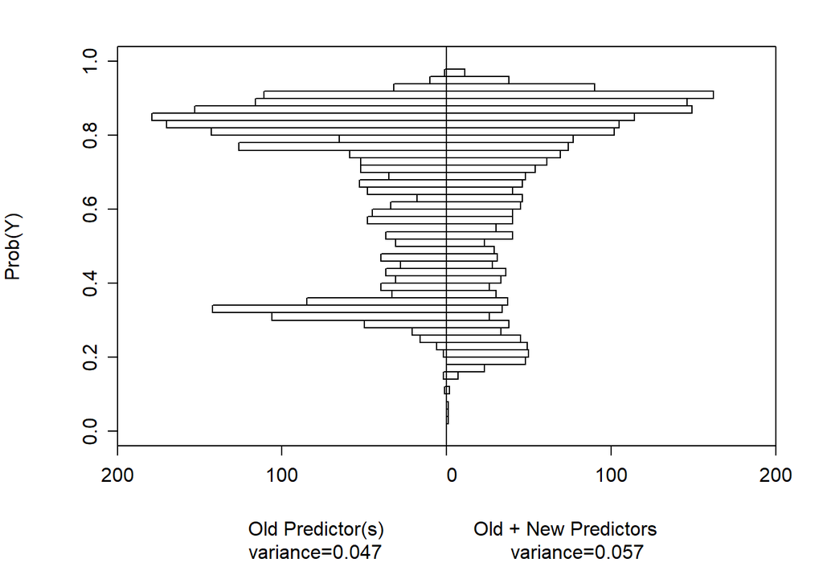

Histbackback plots

```r
plot(hresults)
```

## Ordinal models

### Yardsticks

**kint = 1**

```r
Happy(h, var_comp = ~  tvdlm , B = 500)  # kint = 1 (default)
```

```
Old Predictor(s): rcs(age, 4) + sex
New Predictor(s): tvdlm

                            Values
U test Frac more concordant 0.56
U test  Pval                <0.0001
LR test Pval                <0.0001

Bootstrap 0.95 confidence intervals for Adequacy Index
and REV yardsticks based on 500 bootstraps

                             Values Lower Upper
LR-based Adequacy Index      0.434  0.221 0.718
Frac of new info (AI_LR)     0.566  0.282 0.779
Relative explained variation 0.472  0.235 0.754
Frac of new info (REV)       0.528  0.246 0.765
R^2-based Adequacy Index     0.393  0.157 0.699
Frac of new info (AI_R2)     0.607  0.301 0.843
```

**kint = 3**

```r
Happy(h, var_comp = ~  tvdlm , kint = 3, B = 500)
```

```
Old Predictor(s): rcs(age, 4) + sex
New Predictor(s): tvdlm

                            Values
U test Frac more concordant 0.551
U test  Pval                1e-04
LR test Pval                <0.0001

Bootstrap 0.95 confidence intervals for Adequacy Index
and REV yardsticks based on 500 bootstraps

                             Values Lower Upper
LR-based Adequacy Index      0.434  0.234 0.711
Frac of new info (AI_LR)     0.566  0.289 0.766
Relative explained variation 0.409  0.211 0.695
Frac of new info (REV)       0.591  0.305 0.789
R^2-based Adequacy Index     0.393  0.171 0.683
Frac of new info (AI_R2)     0.607  0.317 0.829
```

### Visualization

**kint = 1**

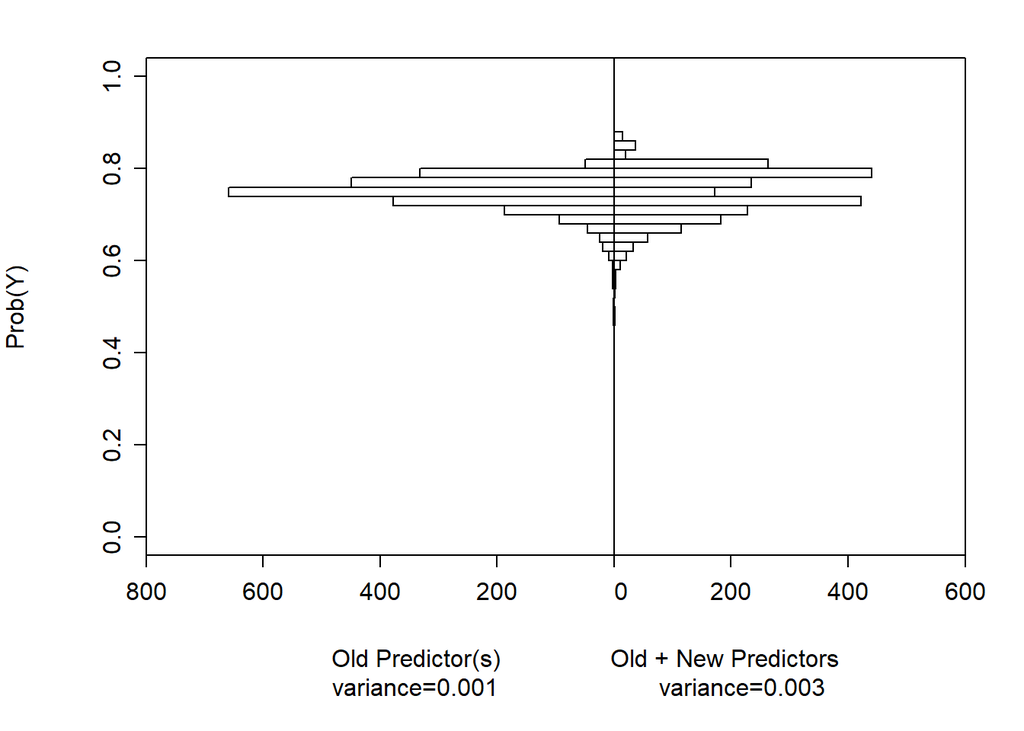

Histbackback (kint1)

```r
plot(Happy(h, var_comp = ~  tvdlm))
```

**kint = 3**

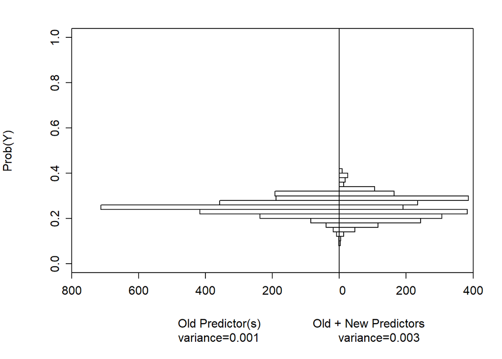

Histbackback (kint3)

```r
plot(Happy(h, var_comp = ~  tvdlm, kint =3))
```

## Acknowledgement

Special thanks to Prof Harrell for his guidance and his suggestion to create this online vignette. All mistakes in this vignette, however, are mine.

Happy using `Happy` 🙂

**Happy.R**

```r
#'
#'
#' Harrell's added predictive performance yardstick (Happy)
#'
#' Compute the various added predictive performance yardsticks/indexes for binary/ordinal outcome models. This function is inspired by
#' Prof Harrell's thoughtful and thought-provoking blog article https://www.fharrell.com/post/addvalue/
#'
#' Summary
#' Yardstick 1:  U-statistic test, implemented in Hmisc::rcorrp.cens(), assesses whether the expanded model with the new predictor(s) gives
#' predictions that are more concordant with the binary outcome than do the base model.
#' Warning: Whilst this test is an improvement over taking the difference between two c-indexes, it is less powerful than its LR-based counterparts.
#'
#' Yardstick 2: LR chi-squared test formally compares the base model with the expanded model which includes the new predictor(s)
#'
#' Yardstick 3: Adequacy Index: Ratio of LR_base/LR_expanded evaluates adequacy of the base model that excludes the new predictor(s)
#'
#' Yardstick 4: Relative Explained Variation (REV): Ratio of variances of predicted values before and after adding the new predictor(s) to
#' the base model. (1 - REV) gives the proportion of the total explained variation of the outcome that is explained by the new predictor(s)
#'
#' Yardstick 5 (experimental!): R^2-based Adequacy Index: Ratio of R^2_base/R^2_expanded evaluates adequacy of the base model,
#' where R^2 refers to the modified adjusted Maddala-Cox-Snell (MCS) R^2 value with (i) overfitting (regression parameter)
#' adjustment and (ii) effective sample size adjustment
#'
#'
#'
#'
#' @title Harrell's added predictive performance yardstick (Happy)
#' @param m1           An object of class \code{lrm} or \code{orm} representing a base model or an expanded model that includes `var_comp`
#' @param var_comp     a formula with no left hand side variable, specifying the new or competing predictor(s)
#' @param B            number of bootstrap resamples to do to get confidence intervals for the Adequacy Index and Relative Explained Variation
#' @param kint         single integer specifying the number of the intercept to use in multiple-intercept (ordinal) models. The default is 1 for `lrm` models
#'
#' @return
#' @export
#'
#' @examples
#'
#'

Happy <- function (m1, var_comp = NULL, B = 0, kint = 1) {

  #' Ensure that lrm and orm objects are supplied
  if(!any(class(m1) %in% Cs(lrm, orm))) {
    stop('m1 must be of class lrm or orm', call. = FALSE)
  }

  #' Extract formula and term.labels from m1 and var_comp
  m1_formula <- m1$sformula
  tl_m1 <- attr(terms(m1_formula), "term.labels")
  tl_m2 <- attr(terms(var_comp), "term.labels")


  if( length(tl_m2) > 1 )
    if ( length (setdiff(tl_m1, tl_m2)) == 0 )
      stop ("m1 and var_comp are the same" )


  if( length(tl_m2) > 1 )
    if (!all(tl_m2 %in% tl_m1) & any(tl_m2 %in% tl_m1))
      stop ("some var_comp terms are not found in m1" )

  if (all(tl_m2 %in% tl_m1)) {
    warning ("var_comp found in m1")

    modA_formula  <- update(m1$sformula, paste(". ~ ",  paste (setdiff(tl_m1, tl_m2), collapse = " + "  )))
    modAB_formula <- m1_formula

  } else {

    modA_formula  <- m1_formula
    modAB_formula <- as.formula (paste( deparse(m1_formula),  as.character(var_comp)[-1], sep = "+" ))
  }

  ## Generate dataset with no missing values
  mydata = m1$call$data
  mydata = eval (mydata) [ , all.vars(modAB_formula)]
  mydata <- mydata [complete.cases(mydata), ]


  #' create all models
  mod_A  <- try(lrm(modA_formula, data = mydata), silent = TRUE)
  mod_AB <- try(lrm(modAB_formula, data = mydata), silent = TRUE)
  if(length(mod_A$fail) && mod_A$fail) stop ("Unable to fit base model")
  if(length(mod_AB$fail) && mod_AB$fail) stop ("Unable to fit expanded model")


  #' ensure valid kint values
  yunique  <- sort(unique( mydata[,1] ))[-1]  # remove lowest level to match kint
  isbinary <- length(yunique) == 1
  if (kint < 1) stop ("kint is a positive integer")
  if (isbinary) kint <- 1
  if (!isbinary & kint > length(yunique) ) stop ("kint exceeds max outcome levels")

  #' plogis() to get predicted Y
  Ypred_A  <- plogis(predict(mod_A, kint = kint))
  Ypred_AB <- plogis(predict(mod_AB, kint = kint))


  #' Yardstick 1: U-statistic test to assess concordance of mod_A and mod_AB with binary outcome

  rr <- rcorrp.cens( Ypred_AB, Ypred_A,
                     if (!isbinary) ifelse (mydata[,1] >= yunique[kint], 1, 0)  else mydata[,1])
  concord_p <- 2* pnorm(-abs ( rr[['Dxy']] / rr[['S.D.']] ) )

  #' Yardstick 2: LRx2 test to evaluate incremental prognostic/predictive value of mod_B above mod_A
  ltest <- try(rms::lrtest(mod_A, mod_AB), silent=TRUE)


  #' Yardstick 3: Adequacy Index  = LR_A / LR_AB
  #' Yardstick 4: Relative Explained Variation (REV) derived from variance of predicted probabilities
  #' Yardstick 4: Proportion of prognostic information of expanded model (modd_AB) that is attributed to var_A

  hrev_fun <- function (ma, mab, kint = kint) {

    # compute Adequacy Index (AI) and Relative Explained Variation (REV)
    dev_a   <- deviance(ma)
    dev0_a  <- dev_a[1]
    dev_a   <- dev_a[length(dev_a)]
    LR_a    <- dev0_a - dev_a

    dev_ab   <- deviance(mab)
    dev0_ab  <- dev_ab[1]
    dev_ab   <- dev_ab[length(dev_ab)]
    LR_ab    <- dev0_ab - dev_ab

    ma_var   <- var(plogis(predict(ma,  kint = kint)), na.rm = TRUE)
    mab_var  <- var(plogis(predict(mab, kint = kint)), na.rm = TRUE)

    # compute modified adjusted MCS R^2
    ytable_a <- ma$freq
    ytable_ab <- mab$freq

    kint_a <- length(names(ytable_a)) - 1
    kint_ab <- length(names(ytable_ab)) - 1

    df_a <- length(coef(ma))
    df_ab <- length(coef(ma))

    p_a  <- df_a  - kint_a
    p_ab <- df_ab - kint_ab

    n <- ma$stats["Obs"]
    r2m_a <-  Hmisc::R2Measures(LR_a,   p_a,  n, ytable_a)
    r2m_ab <- Hmisc::R2Measures(LR_ab, p_ab, n, ytable_ab)

    data.frame (`LR-based Adequacy Index`     = LR_a/LR_ab,
                `Frac of new info (AI_LR)`       = 1 - (LR_a/LR_ab),
                `Relative explained variation`= ma_var/mab_var,
                `Frac of new info (REV)`      = 1 - (ma_var/mab_var),
                `R^2-based Adequacy Index`     = r2m_a[4]/r2m_ab[4],
                `Frac of new info (AI_R2)`       = 1 - (r2m_a[4]/r2m_ab[4]),
                check.names=FALSE)
  }


  #' B > 0, bootstrap AI and REV (Yardsticks 3 and 4)
  nboot <- 0
  boot  <- array(NA, c(B, 6),
                 dimnames=list(NULL,
                               c('AI', 'Frac_AI', 'REV', 'Frac_REV', 'R2_AI', 'R2_Frac_AI')))

  if(B > 0) {
    for(i in 1 : B) {

      j   <- sample(nrow(mydata), nrow(mydata), replace=TRUE)
      mydat <- mydata[j, ]

      # fit bootstrap models
      bmod_A  <-   lrm(modA_formula, data = mydat)
      bmod_AB <-   lrm(modAB_formula, data = mydat)

      if (length(bmod_A$fail) && bmod_A$fail)   next
      if (length(bmod_AB$fail) && bmod_AB$fail) next

      nboot <- nboot + 1
      boot[nboot, ]         <-  as.matrix(hrev_fun(bmod_A, bmod_AB, kint = kint))
    }

    if(nboot < B) boot <- boot[1 : nboot,  , drop=FALSE]

    }

  # Consolidate test results

  stats <-
    data.frame ( `U test Frac more concordant`     = rr["x1 more concordant"] ,
                 `U test  Pval`                    = concord_p ,
                 `LR test Pval`                    = ltest$stats["P"],
                 hrev_fun(mod_A, mod_AB, kint = kint),
              check.names=FALSE)


  structure(
    list(
      ypred_A  = Ypred_A,
      ypred_AB = Ypred_AB,
      mod_A    = as.character(modA_formula)[-c(1,2)],
      mod_B    = as.character(var_comp)[-1],
      stats    = stats,
      nboot    = nboot,
      boot     = if(B > 0) boot),
    class = 'Happy')

  }


#' Print Result from Happy
#'
#' @param x
#' @param ...
#'
#' @return
#' @export
#'
#' @examples
print.Happy <- function(x, ...) {

  fA  <- x$mod_A
  fB  <- x$mod_B

  cat("\nOld Predictor(s): ")
  cat(fA)
  cat("\nNew Predictor(s): ")
  cat(fB)
  cat("\n\n")

  fstats <- x$stats
  pcol   <- names(fstats)[grep('Pval', names(fstats))]  # pval columns

  #' z() taken from print.ImpactPO
  z <- function(x, digits=0, pval=FALSE) {
    y <- if(pval) ifelse(x < 0.0001, '<0.0001', format(round(x, 4)))
    else format(if(digits == 0) x else round(x, digits))
    y[is.na(x)] <- ''
    y
  }

  # fix formatting
  for(j in pcol)                          fstats[[j]] <- z(fstats[[j]], pval = TRUE)
  for(j in setdiff(names(fstats), pcol))  fstats[[j]] <- z(fstats[[j]], 3)

  fstats <- t(fstats)
  colnames(fstats) <- c("Values")

  if(x$nboot > 0) {
    boot <- x$boot

    print(head(fstats, -dim(boot)[[2]]), quote = FALSE)

    cat('\nBootstrap 0.95 confidence intervals for Adequacy Index \nand REV yardsticks based on', x$nboot, 'bootstraps\n\n')

    cl <- function(x) {
      qu <- unname(quantile(x, c(0.025, 0.975)))
      c(Lower=qu[1], Upper=qu[2]) }

    bb     <- round (apply(boot, 2, function(x) cl(x) ) , 3)
    cstats <- t(bb)

    ci_stats <- cbind(tail(fstats, dim(boot)[[2]]), cstats)
    print(ci_stats, quote = FALSE)

    } else  print(fstats, quote = FALSE)

  invisible()

  }





#' Plot Result from Happy
#'
#' @param x
#' @param ...
#'
#' @return
#' @export
#'
#' @examples
plot.Happy <- function(x, ...) {


  pred_A <- x$ypred_A
  pred_AB <- x$ypred_AB

  #' codes taken from blog article
  #' TODO: include the additional plots outlined in blog article + Datamethods
  par(mgp=c(4,1,0), mar=c(6,5,2,2))
  xlab <- c(paste0('Old Predictor(s)\nvariance=',       round(var(pred_A), 3)),
            paste0('Old + New Predictors\nvariance=', round(var(pred_AB), 3)))
  histbackback(pred_A, pred_AB, brks=seq(0, 1, by=0.02), xlab=xlab, ylab='Prob(Y)')


}
```

## Footnotes

[^1]: I don’t mean to be flippant here. To judge from the responses on [Datamethods](https://discourse.datamethods.org/t/statistically-efficient-ways-to-quantify-added-predictive-value-of-new-measurements/2013), I sincerely believe that powerful LR-based yardsticks like AI and REV have made many biomedical researchers very happy.